# BA Assignment 2

Raju Rishikesh Gollapally

2023-10-13

#The Library dplyr is loaded

```r
library(dplyr)
```

#Reading the dataset of Network_Retail.CSV File

```r
library(readr)
Network_Retail <- read.csv("C:/Users/rishi/Downloads/Network_Retail.csv")
View(Network_Retail)
```

#Summary of the table Network_Retail

```r
summary(Network_Retail)
```

```
##   InvoiceNo          StockCode         Description           Quantity
##  Length:541909      Length:541909      Length:541909      Min.   :-80995.00
##  Class :character   Class :character   Class :character   1st Qu.:     1.00
##  Mode  :character   Mode  :character   Mode  :character   Median :     3.00
##                                                           Mean   :     9.55
##                                                           3rd Qu.:    10.00
##                                                           Max.   : 80995.00
##
##  InvoiceDate          UnitPrice           CustomerID       Country
##  Length:541909      Min.   :-11062.06   Min.   :12346    Length:541909
##  Class :character   1st Qu.:     1.25   1st Qu.:13953    Class :character
##  Mode  :character   Median :     2.08   Median :15152    Mode  :character
##                     Mean   :     4.61   Mean   :15288
##                     3rd Qu.:     4.13   3rd Qu.:16791
##                     Max.   : 38970.00   Max.   :18287
##                                         NA's   :135080
```

#Question 1:

```r
total_Transvalue <- nrow(Network_Retail)
total_Transvalue
```

```
## [1] 541909
```

#Transaction volume by nations

```r
country_counts <- Network_Retail %>% group_by(Country) %>% summarize(Count = n())
country_counts
```

| Country | Count |
| --- | --- |
| Australia | 1259 |
| Austria | 401 |
| Bahrain | 19 |
| Belgium | 2069 |
| Brazil | 32 |
| Canada | 151 |
| Channel Islands | 758 |
| Cyprus | 622 |
| Czech Republic | 30 |
| Denmark | 389 |

[output cut: 28 more lines]

#Transaction volume by nations, in percentage

```r
country_counts <- country_counts %>% mutate(Percentage = (Count / total_Transvalue) * 100)
country_counts
```

| Country | Count | Percentage |
| --- | --- | --- |
| Australia | 1259 | 0.232326830 |
| Austria | 401 | 0.073997664 |
| Bahrain | 19 | 0.003506124 |
| Belgium | 2069 | 0.381798420 |
| Brazil | 32 | 0.005905050 |
| Canada | 151 | 0.027864457 |
| Channel Islands | 758 | 0.139875883 |
| Cyprus | 622 | 0.114779419 |
| Czech Republic | 30 | 0.005535985 |
| Denmark | 389 | 0.071783270 |

[output cut: 28 more lines]

#Nations that have been filtered out if they account for more than 1% of all transactions, as determined above.

```r
country_counts_filtered <- country_counts %>% filter(Percentage > 1)
country_counts_filtered
```

| Country | Count | Percentage |
| --- | --- | --- |
| EIRE | 8196 | 1.512431 |
| France | 8557 | 1.579047 |
| Germany | 9495 | 1.752139 |
| United Kingdom | 495478 | 91.431956 |

#Question 2:

```r
Network_Retail$TransactionValue <- Network_Retail$Quantity * Network_Retail$UnitPrice
Network_Retail
```

| InvoiceNo | StockCode | Description | Quantity | InvoiceDate | UnitPrice | CustomerID | Country | TransactionValue |
| --- | --- | --- | --- | --- | --- | --- | --- | --- |
| 536365 | 85123A | WHITE HANGING HEART T-LIGHT HOLDER | 6 | 12/1/2010 8:26 | 2.55 | 17850 | United Kingdom | 15.30 |
| 536365 | 71053 | WHITE METAL LANTERN | 6 | 12/1/2010 8:26 | 3.39 | 17850 | United Kingdom | 20.34 |
| 536365 | 84406B | CREAM CUPID HEARTS COAT HANGER | 8 | 12/1/2010 8:26 | 2.75 | 17850 | United Kingdom | 22.00 |
| 536365 | 84029G | KNITTED UNION FLAG HOT WATER BOTTLE | 6 | 12/1/2010 8:26 | 3.39 | 17850 | United Kingdom | 20.34 |
| 536365 | 84029E | RED WOOLLY HOTTIE WHITE HEART. | 6 | 12/1/2010 8:26 | 3.39 | 17850 | United Kingdom | 20.34 |
| 536365 | 22752 | SET 7 BABUSHKA NESTING BOXES | 2 | 12/1/2010 8:26 | 7.65 | 17850 | United Kingdom | 15.30 |
| 536365 | 21730 | GLASS STAR FROSTED T-LIGHT HOLDER | 6 | 12/1/2010 8:26 | 4.25 | 17850 | United Kingdom | 25.50 |
| 536366 | 22633 | HAND WARMER UNION JACK | 6 | 12/1/2010 8:28 | 1.85 | 17850 | United Kingdom | 11.10 |
| 536366 | 22632 | HAND WARMER RED POLKA DOT | 6 | 12/1/2010 8:28 | 1.85 | 17850 | United Kingdom | 11.10 |
| 536367 | 84879 | ASSORTED COLOUR BIRD ORNAMENT | 32 | 12/1/2010 8:34 | 1.69 | 13047 | United Kingdom | 54.08 |

[output cut: 9990 more lines]

#Question 3:

#Each nation has spent a total amount of money.

```r
country_totals <- Network_Retail %>% group_by(Country) %>% summarize(TotalValue = sum(TransactionValue))
country_totals
```

| Country | TotalValue |
| --- | --- |
| Australia | 137077.27 |
| Austria | 10154.32 |
| Bahrain | 548.40 |
| Belgium | 40910.96 |
| Brazil | 1143.60 |
| Canada | 3666.38 |
| Channel Islands | 20086.29 |
| Cyprus | 12946.29 |
| Czech Republic | 707.72 |
| Denmark | 18768.14 |

[output cut: 28 more lines]

#The nations with total transactions surpassing 130,000 British Pounds are shown below.

```r
filtered_countries <- country_totals %>% filter(TotalValue > 130000)
filtered_countries
```

| Country | TotalValue |
| --- | --- |
| Australia | 137077.3 |
| EIRE | 263276.8 |
| France | 197403.9 |
| Germany | 221698.2 |
| Netherlands | 284661.5 |
| United Kingdom | 8187806.4 |

```r
summary(Network_Retail$InvoiceDate)
```

```
##    Length     Class      Mode
##    541909 character character
```

#Question 4

#As stated in the assignment, we are working with the InvoiceDate variable and printing the time, date, weekday, and month as well as transforming the datatypes of the following.

```r
Temp=strptime(Network_Retail$InvoiceDate,format='%m/%d/%Y %H:%M',tz='GMT')
head(Temp)
```

```
## [1] "2010-12-01 08:26:00 GMT" "2010-12-01 08:26:00 GMT"
## [3] "2010-12-01 08:26:00 GMT" "2010-12-01 08:26:00 GMT"
## [5] "2010-12-01 08:26:00 GMT" "2010-12-01 08:26:00 GMT"
```

```r
Network_Retail$New_Invoice_Date <- as.Date(Temp)
head(Network_Retail$New_Invoice_Date)
```

```
## [1] "2010-12-01" "2010-12-01" "2010-12-01" "2010-12-01" "2010-12-01"
## [6] "2010-12-01"
```

```r
Network_Retail$New_Invoice_Date[20000]- Network_Retail$New_Invoice_Date[10]
```

```
## Time difference of 8 days
```

```r
Network_Retail$Invoice_Day_Week= weekdays(Network_Retail$New_Invoice_Date)
head(Network_Retail$Invoice_Day_Week)
```

```
## [1] "Wednesday" "Wednesday" "Wednesday" "Wednesday" "Wednesday" "Wednesday"
```

```r
Network_Retail$New_Invoice_Hour = as.numeric(format(Temp, "%H"))
head(Network_Retail$New_Invoice_Hour)
```

```
## [1] 8 8 8 8 8 8
```

```r
Network_Retail$New_Invoice_Month = as.numeric(format(Temp, "%m"))
head(Network_Retail$New_Invoice_Month)
```

```
## [1] 12 12 12 12 12 12
```

#(A) Percentage of transactions (measured in numbers) by weekdays

```r
weekday_cnt = Network_Retail %>% group_by(Invoice_Day_Week) %>%
summarise(percent = 100* n()/nrow(Network_Retail))
weekday_cnt
```

| Invoice_Day_Week | percent |
| --- | --- |
| Friday | 15.16731 |
| Monday | 17.55110 |
| Sunday | 11.87930 |
| Thursday | 19.16503 |
| Tuesday | 18.78692 |
| Wednesday | 17.45035 |

#(B)

#Percentage of transactions (based on volume) divided by the number of days in a week

```r
weekday_sum = Network_Retail %>% group_by(Invoice_Day_Week) %>% summarise(sum=sum(TransactionValue))
```

#How to calculate the TransactionValue by weekdays %

```r
weekday_sum_per = 100*(weekday_sum$sum)/sum(weekday_sum$sum)
```

#Substituting the produced value (weekday_sum) for the percentage value

```r
weekday_sum$sum = weekday_sum_per
weekday_sum
```

| Invoice_Day_Week | sum |
| --- | --- |
| Friday | 15.804787 |
| Monday | 16.297194 |
| Sunday | 8.265282 |
| Thursday | 21.671867 |
| Tuesday | 20.170636 |
| Wednesday | 17.790232 |

#(C)

#Percentage of transactions by month over a year (based on transaction volume)

```r
Invoice_month_per = Network_Retail %>% group_by(New_Invoice_Month) %>% summarise(sum=sum(TransactionValue))
Month_per = 100*(Invoice_month_per$sum)/sum(Invoice_month_per$sum)
Invoice_month_per$sum = Month_per
Invoice_month_per
```

| New_Invoice_Month | sum |
| --- | --- |
| 1 | 5.744919 |
| 2 | 5.109515 |
| 3 | 7.009487 |
| 4 | 5.059703 |
| 5 | 7.420519 |
| 6 | 7.090080 |
| 7 | 6.989308 |
| 8 | 7.003469 |
| 9 | 10.460751 |
| 10 | 10.984123 |

[output cut: 2 more lines]

#(D)

#The day when there were the most Australian transactions

```r
Australia_trnx = Network_Retail %>% filter(Country == "Australia") %>% group_by(New_Invoice_Date) %>% summarise(total=n())
```

#The day with the most transactions is

```r
Max_trnx_dt = Australia_trnx[which.max(Australia_trnx$total),]
Max_trnx_dt
```

| New_Invoice_Date | total |
| --- | --- |
| 2011-06-15 | 139 |

#(E)

#Filter the transactions for the IT team’s 7:00–20:00 accessible hours.

```r
Sum_1 = Network_Retail %>% filter(New_Invoice_Hour >= 7) %>% group_by(New_Invoice_Hour) %>% summarise(sum_ans = sum(Quantity))
```

#(install.packages(“zoo”)) installed the “zoo” package.

```r
library("zoo")
```

#The two subsequent rows added

```r
succ_sum=rollapply(Sum_1$sum_ans,2,sum)
```

#Updated Maintenance column

```r
maintain=c(7:19)
```

#The maintain and succ_sum need the creation of the dataframe.

```r
Maintainace_1=data.frame(maintain,succ_sum)
```

#determining the time of day to begin the maintenance

```r
maintain_hr=Maintainace_1[which.min(Maintainace_1$succ_sum),]
maintain_hr
```

|  | maintain | succ_sum |
| --- | --- | --- |
| 13 | 19 | 40298 |

Customers will receive the least amount of distribution if maintenance is begun at 19th Hour.

#Question 5:

#Plotting the German transaction value histogram

```r
german_transac <- Network_Retail %>% filter(Country == "Germany")
```

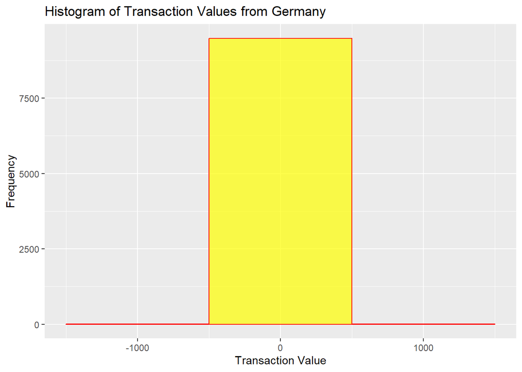

```r
library(ggplot2)
ggplot(german_transac, aes(x = TransactionValue)) + geom_histogram(binwidth = 1000, fill = "yellow", color = "red", alpha = 0.7) +
  labs(title = "Histogram of Transaction Values from Germany",
    x = "Transaction Value",
    y = "Frequency"
  )
```

#Question 6:

#Deleting CustomerID’s null values

```r
NA_Network_Retail=Network_Retail[!is.na(Network_Retail$CustomerID),]

Cnt_trnx = NA_Network_Retail %>% group_by(CustomerID) %>%
summarise(count=n())

Max_Cnt_trnx= Cnt_trnx[which.max(Cnt_trnx$count),]
```

#Number of transactions taking CustomerID into account

```r
Sum_trnx = NA_Network_Retail %>% group_by(CustomerID) %>% summarise(Numo_trnx=(sum(TransactionValue,na.rm = T)))
```

#Maximum number of transactions in a row

```r
Max_Sum_trnx= Sum_trnx[which.max(Sum_trnx$Numo_trnx),]
Max_Cnt_trnx
```

| CustomerID | count |
| --- | --- |
| 17841 | 7983 |

```r
Max_Sum_trnx
```

| CustomerID | Numo_trnx |
| --- | --- |
| 14646 | 279489 |

#Question 7:

#Percentage of variables in the dataset with missing values

```r
NA_percentail = colMeans(is.na(Network_Retail))*100
NA_percentail
```

```
##         InvoiceNo         StockCode       Description          Quantity
##           0.00000           0.00000           0.00000           0.00000
##       InvoiceDate         UnitPrice        CustomerID           Country
##           0.00000           0.00000          24.92669           0.00000
##  TransactionValue  New_Invoice_Date  Invoice_Day_Week  New_Invoice_Hour
##           0.00000           0.00000           0.00000           0.00000
## New_Invoice_Month
##           0.00000
```

#Question 8:

#Transactions for which CustomerID entries are missing, broken down by country:

```r
NA_Customars = Network_Retail[is.na(Network_Retail$CustomerID),]
```

#As stated in the question, separating the missing CustomerID depending on nations

```r
table(NA_Customars$Country)
```

```
##
##        Bahrain           EIRE         France      Hong Kong         Israel
##              2            711             66            288             47
##       Portugal    Switzerland United Kingdom    Unspecified
##             39            125         133600            202
```

#Question 9:

#The clients return to the website:

```r
Move_df <- table(Network_Retail$Invoice_Day_Week,Network_Retail$New_Invoice_Date)
Move_df_New<- diff(Move_df)
mean(Move_df_New)
```

```
## [1] 8.112787
```

#Question 10:

The proportion of French consumers who returned:

```r
French_cust = filter(Network_Retail,Country=="France" )
```

```r
Rto_return = nrow(filter(French_cust,Quantity<1))/nrow(French_cust)
Rto_return
```

```
## [1] 0.01741264
```

#Question 11:

#The item that has brought in the most money for the merchant is:

#Initial item revenue calculations are done.

```r
rev_product= Network_Retail %>% group_by(StockCode) %>% summarise(Sum_trnxval = sum(TransactionValue))
```

#Identifying the item with the greatest overall ‘TransactionValue’ will now yield the top income item.

```r
rev_product[which.max(rev_product$Sum_trnxval),]
```

| StockCode | Sum_trnxval |
| --- | --- |
| DOT | 206245.5 |

#Question 12:

#Number of distinct consumers overall in the dataset

```r
length(unique(Network_Retail$CustomerID))
```

```
## [1] 4373
```